# Data Import; {readxl}

2020-09-15 13:16:12

## Lesson Aim

[figure not shown]

- Learn about importing Microsoft Office Excel files
- Excel is still widely used
- Most people that do knot know of “tidy” data provide “messy” data
- Even people that do know “tidy” data do not always provide “tidy” data

## The Excel Enigma

- Excel is not meant for data wrangling
- It is not really meant for visualizations either
- It is meant for rectangular data, but nobody does it!

## Reading .xls and .xlsx with {readxl}

- There are many R packages that can read Excel files
- {readxl} does not need any external dependencies
- It applies the {tidyverse} logic

## Real-life example

[figure not shown]

```r
path_to_messy_excel <- file.path(root, "images", "messy_excel.png")
knitr::include_graphics(path_to_messy_excel, dpi = 110)
```

## Let’s read this messy Excel file into R

```r
path_to_messy_excel_data <- file.path(root, "data", "messy_excel.xlsx")
messy <- readxl::read_excel(path = path_to_messy_excel_data, sheet = 1 )
```

```
## * `` -> ...2
## * `` -> ...3
## * `` -> ...4
## * `` -> ...5
## * `` -> ...6
## * ...
```

```r
head(messy, 8)
```

```
## # A tibble: 8 x 14
##   `Correlation LL… ...2  ...3  ...4  ...5  ...6  ...7  ...8  ...9  ...10 ...11
##   <chr>            <chr> <chr> <chr> <chr> <chr> <chr> <chr> <chr> <chr> <chr>
## 1 <NA>             <NA>  <NA>  <NA>  <NA>  <NA>  <NA>  <NA>  <NA>  <NA>  <NA>
## 2 Compound         EC3   EC50… <NA>  <NA>  <NA>  <NA>  <NA>  IL-1… <NA>  <NA>
## 3 <NA>             <NA>  HU    DisF… VUmc  BASF  Aver… St.d… HU    DisF… VUmc
## 4 Benzocaine       6.57  21.4… 37.0… 17.4… 17.4… 23.3… 9.31… 19.8… not … 7.91…
## 5 Citral           13    5.07… 4.63… 4.45… 5.82… 4.99… 0.61… 4.11… 1.70… 3.66…
## 6 Euganol          13    16.3… 16.3… 8.75… 9.30… 12.6… 4.21… 4.33… 17.4… 4.86…
## 7 x-Hexylcinnamal… 11    130.… 77.2… 78.6… 72.7… 89.7… 27.1… 41.4… 63.7… 20.3…
## 8 2-Mercaptobenzo… 1.7   10.7… 15.23 16.9… not … 14.3… 3.18… 6.25  11.06 4.36…
## # … with 3 more variables: ...12 <chr>, ...13 <chr>, ...14 <chr>
```

## So that didn’t work, now what

- There is stuff at the top that we do not need
- There is stuff at the bottom that we do not
- The datset contains different variables, which?

## Variables in the dataset:

- Laboratory
- EC50
- IL-1alpha_2x
- EC3
- Compound

How do we extract these and make the data tidy?

## Splitting the set into two:

`EC50` and `IL-1alpha_2x` are side-by-side

```r
?read_excel

library(readxl)
EC50 <- readxl::read_excel(path = path_to_messy_excel_data,
                           sheet = 1,
                           range = cell_cols("C:F"),
                           na = c("not tested"),
                           col_names = c("hu", "disfeb",                                                "vumc", "basf")
)

head(EC50, 8)
```

```
## # A tibble: 8 x 4
##   hu                 disfeb             vumc               basf
##   <chr>              <chr>              <chr>              <chr>
## 1 EC50 (mg/ml)       <NA>               <NA>               <NA>
## 2 HU                 DisFeB             VUmc               BASF
## 3 21.451848249027233 37.022292993630572 17.451475155279503 17.420000000000002
## 4 5.0781348613187181 4.6343524676233807 4.4529063025995894 5.8247280334728027
## 5 16.303003533568901 16.328161007835305 8.758893280632412  9.3091582848067773
## 6 130.25362318840581 77.217898832684824 78.603794958935154 72.779922779922771
## 7 10.782553437319468 15.23              16.947058823529414 <NA>
## 8 5.5552935188327126 2.7190859798605733 1.797752808988764  5.3808723640399556
```

## IL-1 alpha

```r
IL1alpha <- readxl::read_excel(path = path_to_messy_excel_data,
                           sheet = 1,
                           range = cell_cols("I:L"),
                           na = c("not tested", "not reached"),
                           col_names = c("hu", "disfeb",                                                "vumc", "basf")
)
head(IL1alpha)
```

```
## # A tibble: 6 x 4
##   hu                 disfeb             vumc               basf
##   <chr>              <chr>              <chr>              <chr>
## 1 IL-1α2x (mg/ml)    <NA>               <NA>               <NA>
## 2 HU                 DisFeB             VUmc               BASF
## 3 19.870410839160833 <NA>               7.91706559523272   18.054951799147343
## 4 4.1115306451612907 1.7077607933719012 3.6620395107888406 4.1983205875003673
## 5 4.3359634551495017 17.468267918787522 4.8638154455932208 8.2720666644244485
## 6 41.442848884786656 63.702226772658413 20.354862021979699 126.3199465021474
```

## Cleaning up the data further

You will notice that there are a number of strange records in the data. Probably due to merging of cells?

Extract the actual data with indexing

```r
EC50 <- EC50[c(3:15), ]
IL1alpha <- IL1alpha[c(3:15), ]
```

## Adding an extra variable with compound names

```r
chemical_names <- readxl::read_excel(path_to_messy_excel_data,
                                     range = cell_cols("A"))

chemical_names <- chemical_names[c(4:16), ]
chemical_names <- chemical_names$`Correlation LLNA-EC3 data`


EC50$chemical_names <- chemical_names
IL1alpha$chemical_names <- chemical_names
```

## Adding a new variable on the `read_out` variable

```r
EC50$read_out <- c("ec50")
IL1alpha$read_out <- c("il_1_alpha")
```

## Combining the two data

We can combine the data now.

```r
library(dplyr)
tidy <- bind_rows(EC50, IL1alpha)
```

## Complete Cases

```r
tidy <- tidy[complete.cases(tidy), ]
```

## Gather all the nummeric variables into one

The variables called `hu` to `basf` are actually no variables We can `gather()` these variables into onw called `laboratory` and put the numeric value in `result`

```r
library(tidyr)
tidy <- tidy %>%
  gather(hu:basf, key = laboratory, value = result)
```

## Checking variable class

```r
str(tidy)
```

```
## tibble [68 × 4] (S3: tbl_df/tbl/data.frame)
##  $ chemical_names: chr [1:68] "Benzocaine" "Citral" "Euganol" "x-Hexylcinnamaldehyde" ...
##  $ read_out      : chr [1:68] "ec50" "ec50" "ec50" "ec50" ...
##  $ laboratory    : chr [1:68] "hu" "hu" "hu" "hu" ...
##  $ result        : chr [1:68] "21.451848249027233" "5.0781348613187181" "16.303003533568901" "130.25362318840581" ...
```

```r
tidy$chemical_names <- as.factor(tidy$chemical_names)
tidy$read_out <- as.factor(tidy$read_out)
tidy$laboratory <- as.factor(tidy$laboratory)
tidy$result <- as.numeric(tidy$result)
```

## Rounding digits

```r
tidy$result <- round(tidy$result, 2)
```

## Final result

```r
tidy
```

```
## # A tibble: 68 x 4
##    chemical_names             read_out   laboratory result
##    <fct>                      <fct>      <fct>       <dbl>
##  1 Benzocaine                 ec50       hu          21.4
##  2 Citral                     ec50       hu           5.08
##  3 Euganol                    ec50       hu          16.3
##  4 x-Hexylcinnamaldehyde      ec50       hu         130.
##  5 Cinnamaldehyde             ec50       hu           5.56
##  6 Isoeuganol                 ec50       hu          13.7
##  7 Formaldehyde               ec50       hu           4.41
##  8 1-chloro-2,4-dinitrobezene ec50       hu           0.78
##  9 Oxazolone                  ec50       hu           4.36
## 10 Citral                     il_1_alpha hu           4.11
## # … with 58 more rows
```

## Plotting the result

We will make two plot to start the Exploratory Data Analysis. Which chemical do you think is the most potent?

What do you think of the correlation between the EC3 and the IL1-alpha values?

## EC3 values

```r
library(ggplot2)
## read EC3
EC3 <- readxl::read_excel(path_to_messy_excel_data,
                       range = cell_cols("A:B"))
```

```
## * `` -> ...2
```

```r
EC3 <- EC3[c(4:16), ]
names(EC3) <- c("chemical_names", "result")
EC3$result <- as.numeric(EC3$result)
EC3$chemical_names <- as.factor(EC3$chemical_names)
```

## Potency

```r
## plot
potency <- tidy %>%
ggplot(aes(x = reorder(chemical_names,
                       result, FUN= mean),
           y = result)) +
  geom_point() +
  geom_smooth() +
  facet_grid(read_out ~ laboratory) +
  coord_flip() +
  ylab("Result (mg/ml") +
  xlab("Chemical names") +
  ggtitle("Per lab and per chemical")
```

## Plot potency

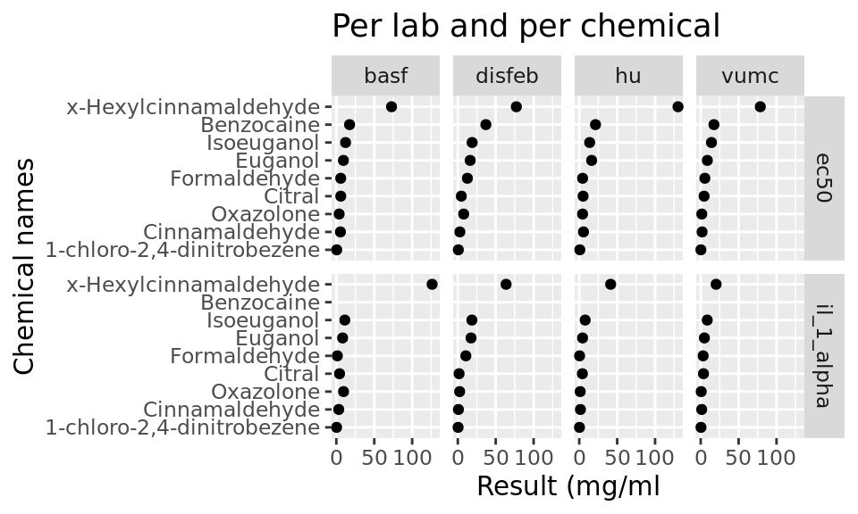

```r
potency
```

Correlation

```r
names(EC3)[2] <- "ec3"
combined <- left_join(tidy, EC3, by = "chemical_names")

only_hu <- combined %>%
  filter(read_out == "il_1_alpha", laboratory == "hu")

cor <- cor.test(only_hu$result, only_hu$ec3)

correlation <- only_hu %>%
ggplot(aes(x = result,
           y = ec3)) +
  geom_point() +
  geom_smooth(method = "lm") +
  xlab("IL-1a") +
  ylab("EC3") +
  ggtitle("Relation between EC50 and EC3 for HU") +
  geom_text(aes(label = chemical_names, hjust = 0.2, vjust = -.4)) +
  geom_jitter(position = "jitter")
```

## Plot

[figure not shown]

```r
correlation
```

```r
cor
```

```
##
##  Pearson's product-moment correlation
##
## data:  only_hu$result and only_hu$ec3
## t = 1.2501, df = 6, p-value = 0.2578
## alternative hypothesis: true correlation is not equal to 0
## 95 percent confidence interval:
##  -0.3679649  0.8780016
## sample estimates:
##       cor
## 0.4545777
```